# 14. 생존분석

```python
from os.path import basename, exists

def download(url):
    filename = basename(url)
    if not exists(filename):
        from urllib.request import urlretrieve
        local, _ = urlretrieve(url, filename)
        print('Downloaded ' + local)

download('https://github.com/AllenDowney/ThinkBayes2/raw/master/soln/utils.py')

from utils import set_pyplot_params
set_pyplot_params()
```

```python
download('https://github.com/AllenDowney/ThinkBayes2/raw/master/soln/utils.py')
```

## 14.01. 와이블분포

#### [와이블분포](https://en.wikipedia.org/wiki/Weibull_distribution)는 여러 범위의 제품 수명 분포를 나타내는 데 좋은 모델, 생존 분석에서 사용

- 와이블분포는 아래와 같이 $\text{2}$개의 모수를 취하며 이산확률분포에서 이항확률분포의 시행 횟수가 $\text{1}$이면 베르누이 확률분포가 되고, 이항확률분포의 시행수를 크게하면 정규확률분포로 이항확률분포를 추정할 수 있는 것과 같이, $\beta$라는 변수에 의해 여러다른 연속확률분포에 근사하여 추정할 수 있게 해주는 특징이 있는 연속확률분포이다.

$$X\sim Weibull(\lambda, k)\;\;\;\lambda > 0,\;\;k > 0$$

#### 확률밀도 함수: $f(x; \lambda, k) = \dfrac{k}{\lambda}(\dfrac{x}{\lambda})^{(k-1)}e^{-(\dfrac{x}{\lambda})^k}$

#### 누적확률밀도함수: $F_x(x) = P(X \leq x) = 1 - e^{(-(\dfrac{x}{\lambda})^\beta)}$

#### $E(X)= \lambda \Gamma(1+\frac{1}{k})$

#### $V(X) = \lambda^2 [\Gamma(1+\frac{2}{k}) - (\Gamma(1+\frac{1}{k}))^2]$

- $k$는 와이블분포의 형태을 결정짓는(데이터가 분포된 방법을 묘사) 형상모수$\text{(Shape Parameter)}$라고 하며, 와이블 확률분포에서 확률분포의 기울기를 의미
- $\lambda$는 분포의 축소 및 확장을 의미하는 스케일 모수인 척도모수$\text{(Scale Parameter)}$
  - $k<1$ : **실패율이 시간이 지남에 따라 감소**
  - $k=1$ : **고장률이 시간이 지나도 일정, 이는 무작위 외부 이벤트로 인해 사망 또는 고장이 발생**
  - $k>1$ : **시간이 지남에 따라 실패율이 증가한다는 것을 나타냅니다. 이는 "노화" 프로세스가 있거나 시간이 지남에 따라 고장날 가능성이 높은 부품이 있는 경우에 발생**
- 어떤 제품의 수명시간 $\text{X}$가 형상모수 $\text{2.2}, 척도모수 \text{1,200}$인 와이블 분포를 따른다고 할 때, 이 제품이 적어도 $\text{1,500}$ 시간 이상 작동할 확률 = $1-80.482\%=19.518\%$

$$f(x; \lambda, \beta) = \dfrac{\beta}{\lambda}(\dfrac{x}{\lambda})^{(\beta-1)}e^{-(\dfrac{x}{\lambda})^\beta} = (\dfrac{2.2}{1200})(\dfrac{1500}{1200}^{(2.2-1)})e^{-(\dfrac{1500}{1200})^{2.2}} = 0.00047$$$$F_x(x) = P(X \leq x) = 1 - e^{\Big(-\Big(\dfrac{x}{\lambda}\Big)^\beta\Big)} = P(X \leq 1500) = 1-e^{\Big(-\Big(\dfrac{1500}{1200}\Big)^{2.2}\Big)} = 0.80482$$$$F_x(x) = P(X \geq x) = e^{\Big(-\Big(\dfrac{x}{\lambda}\Big)^\beta\Big)} = P(X \geq 1500) = e^{\Big(-\Big(\dfrac{1500}{1200}\Big)^{2.2}\Big)} = 0.19518$$

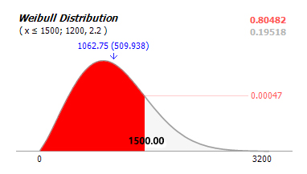

- $k<1$일 경우, 초기에는 아주 많은 실패 또는 고장 확률을 나타내는 것이라 할 수 있고 시간이 갈 수록 점차 그 정도가 줄어드는 확률분포

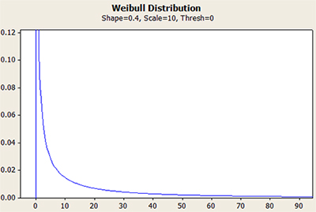

- $k=1$일 경우, 분포의 스케일을 의미하는 척도모수 $\lambda = \dfrac{1}{\lambda}$로 일정한 비율를 따르는 지수확률분포

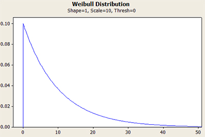

- $1<k<2$일 경우, 확률분포는 빠르게 최대 확률을 기록한 뒤, 빨리 급감하는 새로운 제품의 초기 마모률을 나타내는 확률분포

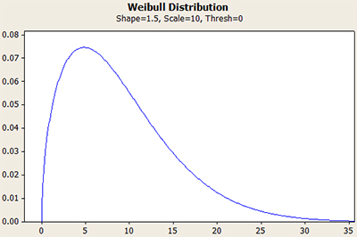

- $k=2$일 경우, 시간의 흐름에 따른 확률의 상승정도가 완만하게 선형적으로 증가하는 것을 볼 수 있다. $k$가 2일 때의 확률분포를 레일리 확률분포$\text{(Rayleigh distribution)}$라 하며, 일정한 제품 생명주기 동안에 일정하게 증가하는 제품 마모고장율에 대한 확률분포를 표현하는 확률분포로 사용

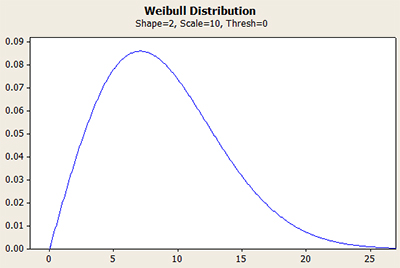

- $3<k<4$일 경우, 정규분포처럼 중간을 기준으로 좌.우가 대칭인 종 모양

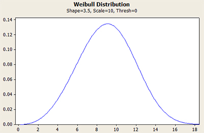

- $k>10$인 경우, 제품수명주기 마지막 단계에서 에서 제품 마모 고장율이 가장 빈번하게 발생하는 경우의 확률분포에서 많이 볼 수 있는 분포

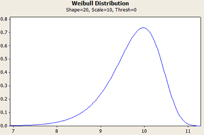

### `scipy.stats.weibull_min(k, scale)` : `k`를 형상모수, `scale`을 척도모수로 갖는 와이블분포 객체 생성

```python
from scipy.stats import weibull_min
```

```python
def weibull_dist(lam, k):
    return weibull_min(k, scale=lam)
```

- $\lambda=3$과 $k=0.8$를 갖는 와이블분포

```python
lam = 3
k = 0.8
actual_dist = weibull_dist(lam, k)
```

```python
import numpy as np
from empiricaldist import Cdf
from utils import decorate
```

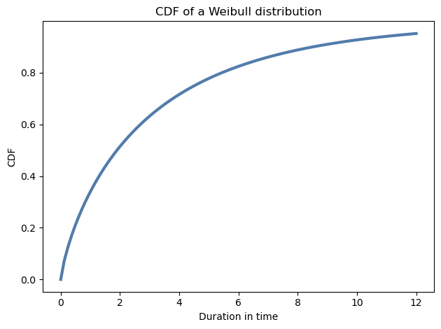

```python
qs = np.linspace(0, 12, 101)
ps = actual_dist.cdf(qs)
cdf = Cdf(ps, qs)
cdf.plot()

decorate(xlabel='Duration in time', ylabel='CDF', title='CDF of a Weibull distribution')
```

```python
np.random.seed(17)
```

```python
data = actual_dist.rvs(10)
data
```

```
array([0.80497283, 2.11577082, 0.43308797, 0.10862644, 5.17334866,
       3.25745053, 3.05555883, 2.47401062, 0.05340806, 1.08386395])
```

#### $\lambda$에 대한 사전균등분포

```python
from utils import make_uniform
```

```python
lams = np.linspace(0.1, 10.1, num=101)
prior_lam = make_uniform(lams, name='lambda')
```

#### $k$에 대한 사전균등분포

```python
ks = np.linspace(0.1, 5.1, num=101)
prior_k = make_uniform(ks, name='k')
```

#### 두 매개변수에 대한 사전결합분포

```python
from utils import make_joint
```

```python
prior = make_joint(prior_lam, prior_k)
```

**첫 축에 $\lambda$를, 두 번째 축에 $k$를, 세 번째 축에 데이터를 넣은 3차원 메쉬 그리드**

```python
lam_mesh, k_mesh, data_mesh = np.meshgrid(prior.columns, prior.index, data)
lam_mesh.shape, k_mesh.shape, data_mesh.shape
```

```
((101, 101, 10), (101, 101, 10), (101, 101, 10))
```

- **각 매개변수의 쌍과 데이터 값에 대한, 와이블분포의 PDF**

```python
densities = weibull_dist(lam_mesh, k_mesh).pdf(data_mesh)
densities.shape
```

```
(101, 101, 10)
```

- **데이터의 가능도는, 세 번째 축 확률 밀도의 외적**

```python
likelihood = densities.prod(axis=2)
likelihood.sum()
```

```
2.0938302958838208e-05
```

### 사전분포 갱신

```python
from utils import normalize
```

```python
posterior = prior * likelihood
normalize(posterior)
```

```
2.052573567183434e-09
```

*위 과정을 하나의 함수로 표현*

```python
def update_weibull(prior, data):
    """사전분포 갱신"""
    lam_mesh, k_mesh, data_mesh = np.meshgrid(prior.columns, prior.index, data)

    densities = weibull_dist(lam_mesh, k_mesh).pdf(data_mesh)
    likelihood = densities.prod(axis=2)

    posterior = prior * likelihood
    normalize(posterior)

    return posterior
```

```python
posterior = update_weibull(prior, data)
posterior
```

| lambda k | 0.1 | 0.2 | 0.3 | 0.4 | 0.5 | 0.6 | 0.7 | 0.8 | 0.9 | 1.0 | ... | 9.2 | 9.3 | 9.4 | 9.5 | 9.6 | 9.7 | 9.8 | 9.9 | 10.0 | 10.1 |
| --- | --- | --- | --- | --- | --- | --- | --- | --- | --- | --- | --- | --- | --- | --- | --- | --- | --- | --- | --- | --- | --- |
| 0.10 | 2.460247e-10 | 2.869778e-10 | 3.057983e-10 | 3.162866e-10 | 3.226332e-10 | 3.266087e-10 | 3.291035e-10 | 3.306176e-10 | 3.314542e-10 | 3.318079e-10 | ... | 2.664361e-10 | 2.658733e-10 | 2.653152e-10 | 2.647618e-10 | 2.642129e-10 | 2.636686e-10 | 2.631288e-10 | 2.625933e-10 | 2.620622e-10 | 2.615354e-10 |
| 0.15 | 8.156967e-09 | 1.187054e-08 | 1.384386e-08 | 1.502215e-08 | 1.576686e-08 | 1.624951e-08 | 1.656276e-08 | 1.676121e-08 | 1.687912e-08 | 1.693904e-08 | ... | 1.072871e-08 | 1.068125e-08 | 1.063429e-08 | 1.058785e-08 | 1.054190e-08 | 1.049643e-08 | 1.045145e-08 | 1.040694e-08 | 1.036289e-08 | 1.031930e-08 |
| 0.20 | 6.217741e-08 | 1.281992e-07 | 1.720646e-07 | 2.011509e-07 | 2.207243e-07 | 2.339881e-07 | 2.429293e-07 | 2.488268e-07 | 2.525330e-07 | 2.546332e-07 | ... | 1.200024e-07 | 1.191211e-07 | 1.182519e-07 | 1.173948e-07 | 1.165493e-07 | 1.157154e-07 | 1.148927e-07 | 1.140810e-07 | 1.132802e-07 | 1.124899e-07 |
| 0.25 | 1.761204e-07 | 6.017744e-07 | 9.874233e-07 | 1.283568e-06 | 1.500720e-06 | 1.656640e-06 | 1.766570e-06 | 1.842145e-06 | 1.891990e-06 | 1.922462e-06 | ... | 6.458484e-07 | 6.389076e-07 | 6.320872e-07 | 6.253843e-07 | 6.187961e-07 | 6.123200e-07 | 6.059533e-07 | 5.996935e-07 | 5.935380e-07 | 5.874846e-07 |
| 0.30 | 2.208596e-07 | 1.516063e-06 | 3.269367e-06 | 4.905637e-06 | 6.249060e-06 | 7.287854e-06 | 8.061069e-06 | 8.617344e-06 | 9.001414e-06 | 9.250664e-06 | ... | 2.149654e-06 | 2.118414e-06 | 2.087836e-06 | 2.057902e-06 | 2.028595e-06 | 1.999896e-06 | 1.971791e-06 | 1.944262e-06 | 1.917294e-06 | 1.890872e-06 |
| ... | ... | ... | ... | ... | ... | ... | ... | ... | ... | ... | ... | ... | ... | ... | ... | ... | ... | ... | ... | ... | ... |
| 4.90 | 0.000000e+00 | 0.000000e+00 | 0.000000e+00 | 0.000000e+00 | 0.000000e+00 | 0.000000e+00 | 0.000000e+00 | 0.000000e+00 | 0.000000e+00 | 0.000000e+00 | ... | 2.708110e-37 | 1.600415e-37 | 9.509542e-38 | 5.680704e-38 | 3.411272e-38 | 2.059015e-38 | 1.249078e-38 | 7.614929e-39 | 4.664966e-39 | 2.871433e-39 |
| 4.95 | 0.000000e+00 | 0.000000e+00 | 0.000000e+00 | 0.000000e+00 | 0.000000e+00 | 0.000000e+00 | 0.000000e+00 | 0.000000e+00 | 0.000000e+00 | 0.000000e+00 | ... | 9.648974e-38 | 5.671028e-38 | 3.351426e-38 | 1.991311e-38 | 1.189449e-38 | 7.141776e-39 | 4.310008e-39 | 2.614087e-39 | 1.593278e-39 | 9.757841e-40 |
| 5.00 | 0.000000e+00 | 0.000000e+00 | 0.000000e+00 | 0.000000e+00 | 0.000000e+00 | 0.000000e+00 | 0.000000e+00 | 0.000000e+00 | 0.000000e+00 | 0.000000e+00 | ... | 3.434116e-38 | 2.007293e-38 | 1.179833e-38 | 6.972648e-39 | 4.142836e-39 | 2.474437e-39 | 1.485562e-39 | 8.963945e-40 | 5.435765e-40 | 3.312343e-40 |
| 5.05 | 0.000000e+00 | 0.000000e+00 | 0.000000e+00 | 0.000000e+00 | 0.000000e+00 | 0.000000e+00 | 0.000000e+00 | 0.000000e+00 | 0.000000e+00 | 0.000000e+00 | ... | 1.220894e-38 | 7.097247e-39 | 4.148989e-39 | 2.438868e-39 | 1.441393e-39 | 8.564068e-40 | 5.114909e-40 | 3.070531e-40 | 1.852531e-40 | 1.123191e-40 |
| 5.10 | 0.000000e+00 | 0.000000e+00 | 0.000000e+00 | 0.000000e+00 | 0.000000e+00 | 0.000000e+00 | 0.000000e+00 | 0.000000e+00 | 0.000000e+00 | 0.000000e+00 | ... | 4.335913e-39 | 2.506740e-39 | 1.457489e-39 | 8.521592e-40 | 5.009678e-40 | 2.960925e-40 | 1.759257e-40 | 1.050686e-40 | 6.306904e-41 | 3.804682e-41 |

101 rows × 101 columns

#### 사후결합분포의 등고선 그래프

```python
from utils import plot_contour
```

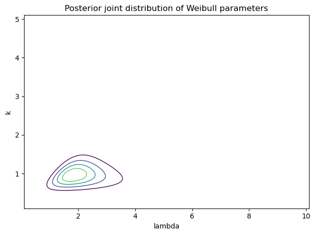

```python
plot_contour(posterior)
decorate(title='Posterior joint distribution of Weibull parameters')
```

#### $\lambda$는 대략 1에서 4에 걸쳐 분포하는 것으로 보이며, 이 안에는 처음에 넣은 값인 3도 포함

#### $k$의 범위는 0.5에서 1.5로, 실제 사용한 0.8이 포함

## 14.02. 주변분포

```python
from utils import marginal
```

```python
posterior_lam = marginal(posterior, 0)
posterior_k = marginal(posterior, 1)
```

#### $\lambda$에 대한 사후주변분포

- 회색 세로선은 $\lambda$의 실제 값 (3)

```python
import matplotlib.pyplot as plt
```

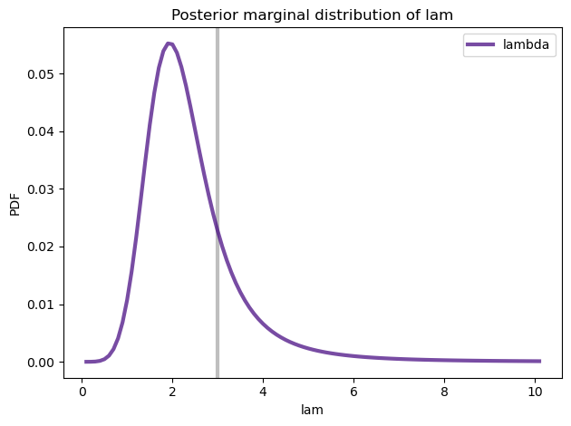

```python
plt.axvline(3, color='C5')
posterior_lam.plot(color='C4', label='lambda')
decorate(xlabel='lam', ylabel='PDF', title='Posterior marginal distribution of lam')
```

- **$\lambda$에 대한 90% 신용구간**

```python
print(lam, posterior_lam.credible_interval(0.9))
```

```
3 [1.2 4.4]
```

#### $k$에 대한 사후주변분포

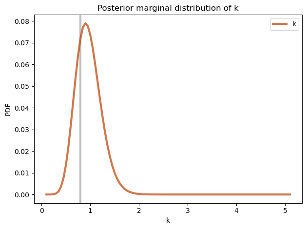

```python
plt.axvline(0.8, color='C5')
posterior_k.plot(color='C12', label='k')
decorate(xlabel='k', ylabel='PDF', title='Posterior marginal distribution of k')
```

- **$k$에 대한 90% 신용구간**

```python
print(k, posterior_k.credible_interval(0.9))
```

```
0.8 [0.6 1.4]
```

#### 10개의 작은 표본으로 인하여, 넓은 신용구간이 형성 되었지만, 두 매개변수의 실제 값 모두 신용구간에 포함됨

## 14.02. 불완전 데이터

- **많은 실제 상황에서, 데이터가 완전하지 않은 경우가 빈번 (표본수가 적음)**
  - 특히 특정 시간에 시스템을 관찰하는 경우, 과거의 정보는 남아있지만 미래에 대한 정보는 없음
  - 예: 유기견 보호소에서, 유기견이 들어온 후, 입양되는 데까지 걸리는 시간에 대해서

    어떤 개는 오자마자 바로 입양자가 나타날 수도 있고, 어떤 개는 오래 기다림

    보호소를 운영하는 사람들은 개들을 임시 보호하는 시간을 추론할 필요가 존재

#### 유기견 보호소에서 8주 간 10마리의 개가 들어왔다가 입양되는 것을 관찰했을 경우

- 개가 들어오는 시간은 균등분포를 따른다고 가정하면

```python
np.random.seed(19)
```

```python
start = np.random.uniform(0, 8, size=10)
start
```

```
array([0.78026881, 6.08999773, 1.97550379, 1.1050535 , 2.65157251,
       0.66399652, 5.37581665, 6.45275039, 7.86193532, 5.08528588])
```

#### 임시보호 시간이 $\lambda=3,\;k=0.8$인 와이블분포를 따른다는 가정

```python
lam = 3
k = 0.8
actual_dist = weibull_dist(lam, k)
```

```python
np.random.seed(17)
```

```python
duration = actual_dist.rvs(10)
duration
```

```
array([0.80497283, 2.11577082, 0.43308797, 0.10862644, 5.17334866,
       3.25745053, 3.05555883, 2.47401062, 0.05340806, 1.08386395])
```

#### 개가 들어오고 나가는 시간에 대한 데이터프레임 생성

```python
import pandas as pd
```

```python
d = dict(start=start, end=start+duration)
obs = pd.DataFrame(d)
```

```python
obs = obs.sort_values(by='start', ignore_index=True)
obs
```

|  | start | end |
| --- | --- | --- |
| 0 | 0.663997 | 3.921447 |
| 1 | 0.780269 | 1.585242 |
| 2 | 1.105053 | 1.213680 |
| 3 | 1.975504 | 2.408592 |
| 4 | 2.651573 | 7.824921 |
| 5 | 5.085286 | 6.169150 |
| 6 | 5.375817 | 8.431375 |
| 7 | 6.089998 | 8.205769 |
| 8 | 6.452750 | 8.926761 |
| 9 | 7.861935 | 7.915343 |

- **몇몇 생존시간선이 관측기간인 8주를 초과**

  **이 경우, 시스템을 8주 시작 시점에 살펴본다면, 일부 정보는 불완전한 상태**
  - 6번, 7번, 8번의 경우 미래의 입양 시점을 알 수 없음

```python
censored = obs['end'] > 8
censored
```

```
0    False
1    False
2    False
3    False
4    False
5    False
6     True
7     True
8     True
9    False
Name: end, dtype: bool
```

```python
obs.loc[censored, 'end'] = 8
obs.loc[censored, 'status'] = 0

obs
```

|  | start | end | status |
| --- | --- | --- | --- |
| 0 | 0.663997 | 3.921447 | NaN |
| 1 | 0.780269 | 1.585242 | NaN |
| 2 | 1.105053 | 1.213680 | NaN |
| 3 | 1.975504 | 2.408592 | NaN |
| 4 | 2.651573 | 7.824921 | NaN |
| 5 | 5.085286 | 6.169150 | NaN |
| 6 | 5.375817 | 8.000000 | 0.0 |
| 7 | 6.089998 | 8.000000 | 0.0 |
| 8 | 6.452750 | 8.000000 | 0.0 |
| 9 | 7.861935 | 7.915343 | NaN |

#### 제한된 관측값과 제한되지 않은 관측값을 나타내는 생존 시간선

```python
def plot_lifelines(obs):
    """각 관측값의 생존 시간선"""
    for y, row in obs.iterrows():
        start = row['start']
        end = row['end']
        status = row['status']

        if status == 0:
            # ongoing
            plt.hlines(y, start, end, color='C0')
        else:
            # complete
            plt.hlines(y, start, end, color='C1')
            plt.plot(end, y, marker='o', color='C1')

    decorate(xlabel='Time (weeks)', ylabel='Dog index', title='Lifelines showing censored and uncensored observations')

    plt.gca().invert_yaxis()
```

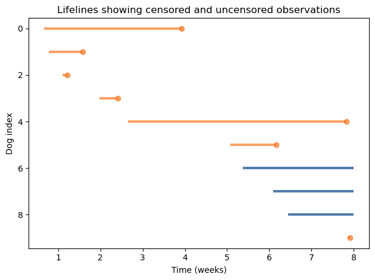

```python
plot_lifelines(obs)
```

#### 각 관측값 별 생존기간

```python
obs['T'] = obs['end'] - obs['start']
obs
```

|  | start | end | status | T |
| --- | --- | --- | --- | --- |
| 0 | 0.663997 | 3.921447 | NaN | 3.257451 |
| 1 | 0.780269 | 1.585242 | NaN | 0.804973 |
| 2 | 1.105053 | 1.213680 | NaN | 0.108626 |
| 3 | 1.975504 | 2.408592 | NaN | 0.433088 |
| 4 | 2.651573 | 7.824921 | NaN | 5.173349 |
| 5 | 5.085286 | 6.169150 | NaN | 1.083864 |
| 6 | 5.375817 | 8.000000 | 0.0 | 2.624183 |
| 7 | 6.089998 | 8.000000 | 0.0 | 1.910002 |
| 8 | 6.452750 | 8.000000 | 0.0 | 1.547250 |
| 9 | 7.861935 | 7.915343 | NaN | 0.053408 |

## 14.03. 불완전한 데이터 사용

#### 완전한 데이터와, 불완전한 데이터 모두를 사용해서, 임시보호 시간의 분포에 대한 모수를 추정

- **데이터를 '도착 및 입양 시점을 모두 아는 개의 임시보호 시간'과, (= 완전 데이터)**

  **'관측 기간동안 입양되지 않은 개의 불완전한 임시보호 시간' 2가지로 분리 (= 불완전 데이터)**

```python
data1 = obs.loc[~censored, 'T']
data2 = obs.loc[censored, 'T']
```

- 완전 데이터

```python
data1
```

```
0    3.257451
1    0.804973
2    0.108626
3    0.433088
4    5.173349
5    1.083864
9    0.053408
Name: T, dtype: float64
```

- 불완전 데이터

```python
data2
```

```
6    2.624183
7    1.910002
8    1.547250
Name: T, dtype: float64
```

#### 완전한 데이터의 경우 와이블분포의 PDF로 데이터의 가능도를 계산

```python
posterior1 = update_weibull(prior, data1)
```

#### 불완전한 데이터의 경우, 관측이 끝나는 시점에서, 보호 시간이 얼마나 더 지속될지 알 수 없음

#### 하지만 보호 시간의 최소한도를 정해두면, 보호시간이 `T`보다는 클 것이라고 추측 가능

#### $\rightarrow$ 즉, 분포의 값이 `T`를 초과할 확률을 구하는 생존 함수를 사용하여 데이터의 가능도를 계산

- **완전데이터의 사후분포를 통하여, 불완전 데이터의 사전분포를 갱신**

```python
def update_weibull_incomplete(prior, data):
    """불완전한 데이터를 사용해서 사전분포를 갱신"""
    lam_mesh, k_mesh, data_mesh = np.meshgrid(prior.columns, prior.index, data)

    """생존함수 계산"""
    probs = weibull_dist(lam_mesh, k_mesh).sf(data_mesh)
    likelihood = probs.prod(axis=2)

    posterior = prior * likelihood
    normalize(posterior)

    return posterior
```

```python
posterior2 = update_weibull_incomplete(posterior1, data2)
```

#### 완전 데이터와, 불완전 데이터에 대한 갱신 이후의 사후결합분포

- **이전 등고선과 비교했을 때, 가능한 $\lambda$의 범위가 상대적으로 넓어짐**

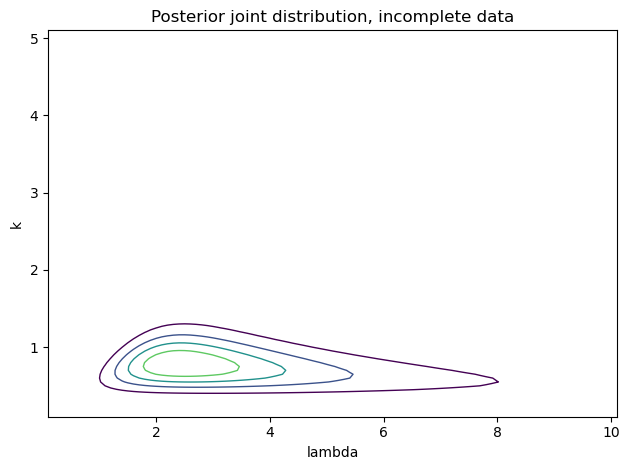

```python
plot_contour(posterior2)
decorate(title='Posterior joint distribution, incomplete data')
```

#### 완전 데이터만을 사용했을 떄와, 제한 데이터를 포함했을 때의 분포에 대한 $\lambda$의 사후주변분포

- **불완전 데이터를 포함한 분포가 상대적으로 폭이 넓음**

```python
posterior_lam2 = marginal(posterior2, 0)
posterior_k2 = marginal(posterior2, 1)
```

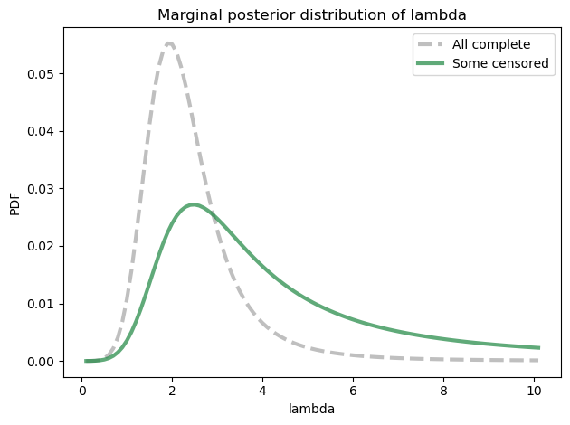

```python
posterior_lam.plot(color='C5', label='All complete', linestyle='dashed')
posterior_lam2.plot(color='C2', label='Some censored')

decorate(xlabel='lambda', ylabel='PDF', title='Marginal posterior distribution of lambda')
```

#### 완전 데이터만을 사용했을 떄와, 제한 데이터를 포함했을 때의 분포에 대한 $k$의 사후주변분포

- **불완전 데이터를 사용한 경우, 주변분포가 왼쪽으로 이동**

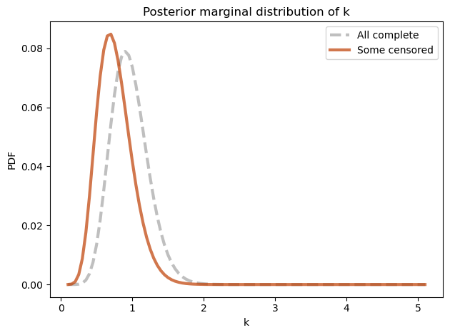

```python
posterior_k.plot(color='C5', label='All complete',linestyle='dashed')
posterior_k2.plot(color='C12', label='Some censored')

decorate(xlabel='k', ylabel='PDF', title='Posterior marginal distribution of k')
```

#### 일반적으로 불완전한 데이터를 사용하는 경우, 정보가 부족함으로 인해 불확실성이 높아짐 $\rightarrow$ 사후분포의 폭이 넓어짐

## 14.04. 전구 수명 분포

2007년의 [전구 수명 분포 파악 실험](https://www.researchgate.net/publication/225450325_Renewal_Rate_of_Filament_Lamps_Theory_and_Experiment)의 내용:

> 40W, 220V (AC)로 매겨진 50개의 새 인도산 필립스 전등 50개를 11m X 7m의 연구실에 동일한 간격을 두고 일렬로 설치

> 12시간 간격으로 전구가 나가는지 확인하여, 수명이 다 한 전구 내역을 기록, 마지막 전구가 나갈 때까지 총 32개의 데이터를 확보
- `h` : 전구가 나갈때까지의 시간
- `f` : 매 시간 나간 전구의 수

```python
download('https://gist.github.com/epogrebnyak/7933e16c0ad215742c4c104be4fbdeb1/raw/c932bc5b6aa6317770c4cbf43eb591511fec08f9/lamps.csv')
```

```python
df = pd.read_csv('lamps.csv', index_col=0)
df.head()
```

| i | h | f | K |
| --- | --- | --- | --- |
| 0 | 0 | 0 | 50 |
| 1 | 840 | 2 | 48 |
| 2 | 852 | 1 | 47 |
| 3 | 936 | 1 | 46 |
| 4 | 960 | 1 | 45 |

```python
from empiricaldist import Pmf
```

```python
pmf_bulb = Pmf(df['f'].to_numpy(), df['h'])
pmf_bulb.normalize()
```

```
50
```

- 전구의 평균 수명은 약 1400시간

```python
pmf_bulb.mean()
```

```
1413.84
```

#### 실험 설계 과정상, 적어도 지속적으로 켜져 있는 전구에 대해서는 이 데이터를 수명 분포를 대표하는 표본으로 간주

- **데이터가 와이블분포를 따른다고 가정하면, 이 데이터에 적합한 매개변수를 추정 가능**
- $\lambda$와 $k$가 사전균등분포를 따른다고 가정

```python
lams = np.linspace(1000, 2000, num=101)
prior_lam = make_uniform(lams, name='lambda')
```

```python
ks = np.linspace(1, 10, num=101)
prior_k = make_uniform(ks, name='k')
```

#### 두 매개변수 $\lambda$와 $k$의 사전결합분포 생성

```python
prior_bulb = make_joint(prior_lam, prior_k)
prior_bulb
```

| lambda k | 1000.0 | 1010.0 | 1020.0 | 1030.0 | 1040.0 | 1050.0 | 1060.0 | 1070.0 | 1080.0 | 1090.0 | ... | 1910.0 | 1920.0 | 1930.0 | 1940.0 | 1950.0 | 1960.0 | 1970.0 | 1980.0 | 1990.0 | 2000.0 |
| --- | --- | --- | --- | --- | --- | --- | --- | --- | --- | --- | --- | --- | --- | --- | --- | --- | --- | --- | --- | --- | --- |
| 1.00 | 0.000098 | 0.000098 | 0.000098 | 0.000098 | 0.000098 | 0.000098 | 0.000098 | 0.000098 | 0.000098 | 0.000098 | ... | 0.000098 | 0.000098 | 0.000098 | 0.000098 | 0.000098 | 0.000098 | 0.000098 | 0.000098 | 0.000098 | 0.000098 |
| 1.09 | 0.000098 | 0.000098 | 0.000098 | 0.000098 | 0.000098 | 0.000098 | 0.000098 | 0.000098 | 0.000098 | 0.000098 | ... | 0.000098 | 0.000098 | 0.000098 | 0.000098 | 0.000098 | 0.000098 | 0.000098 | 0.000098 | 0.000098 | 0.000098 |
| 1.18 | 0.000098 | 0.000098 | 0.000098 | 0.000098 | 0.000098 | 0.000098 | 0.000098 | 0.000098 | 0.000098 | 0.000098 | ... | 0.000098 | 0.000098 | 0.000098 | 0.000098 | 0.000098 | 0.000098 | 0.000098 | 0.000098 | 0.000098 | 0.000098 |
| 1.27 | 0.000098 | 0.000098 | 0.000098 | 0.000098 | 0.000098 | 0.000098 | 0.000098 | 0.000098 | 0.000098 | 0.000098 | ... | 0.000098 | 0.000098 | 0.000098 | 0.000098 | 0.000098 | 0.000098 | 0.000098 | 0.000098 | 0.000098 | 0.000098 |
| 1.36 | 0.000098 | 0.000098 | 0.000098 | 0.000098 | 0.000098 | 0.000098 | 0.000098 | 0.000098 | 0.000098 | 0.000098 | ... | 0.000098 | 0.000098 | 0.000098 | 0.000098 | 0.000098 | 0.000098 | 0.000098 | 0.000098 | 0.000098 | 0.000098 |
| ... | ... | ... | ... | ... | ... | ... | ... | ... | ... | ... | ... | ... | ... | ... | ... | ... | ... | ... | ... | ... | ... |
| 9.64 | 0.000098 | 0.000098 | 0.000098 | 0.000098 | 0.000098 | 0.000098 | 0.000098 | 0.000098 | 0.000098 | 0.000098 | ... | 0.000098 | 0.000098 | 0.000098 | 0.000098 | 0.000098 | 0.000098 | 0.000098 | 0.000098 | 0.000098 | 0.000098 |
| 9.73 | 0.000098 | 0.000098 | 0.000098 | 0.000098 | 0.000098 | 0.000098 | 0.000098 | 0.000098 | 0.000098 | 0.000098 | ... | 0.000098 | 0.000098 | 0.000098 | 0.000098 | 0.000098 | 0.000098 | 0.000098 | 0.000098 | 0.000098 | 0.000098 |
| 9.82 | 0.000098 | 0.000098 | 0.000098 | 0.000098 | 0.000098 | 0.000098 | 0.000098 | 0.000098 | 0.000098 | 0.000098 | ... | 0.000098 | 0.000098 | 0.000098 | 0.000098 | 0.000098 | 0.000098 | 0.000098 | 0.000098 | 0.000098 | 0.000098 |
| 9.91 | 0.000098 | 0.000098 | 0.000098 | 0.000098 | 0.000098 | 0.000098 | 0.000098 | 0.000098 | 0.000098 | 0.000098 | ... | 0.000098 | 0.000098 | 0.000098 | 0.000098 | 0.000098 | 0.000098 | 0.000098 | 0.000098 | 0.000098 | 0.000098 |
| 10.00 | 0.000098 | 0.000098 | 0.000098 | 0.000098 | 0.000098 | 0.000098 | 0.000098 | 0.000098 | 0.000098 | 0.000098 | ... | 0.000098 | 0.000098 | 0.000098 | 0.000098 | 0.000098 | 0.000098 | 0.000098 | 0.000098 | 0.000098 | 0.000098 |

101 rows × 101 columns

#### 실험에는 50개의 전구를 사용했으나, 서로 다른 전구 수명이 32개가 존재

**$\rightarrow$ 각 수명별 관측 횟수 만큼을 반복해서, 50개의 관측값을 생성**

```python
df.shape, df['f'].sum()
```

```
((33, 3), 50)
```

```python
data_bulb = np.repeat(df['h'], df['f'])
len(data_bulb)
```

```
50
```

```python
data_bulb.head()
```

```
i
1    840
1    840
2    852
3    936
4    960
Name: h, dtype: int64
```

#### 사전분포 갱신

```python
posterior_bulb = update_weibull(prior_bulb, data_bulb)
```

#### 사후결합분포

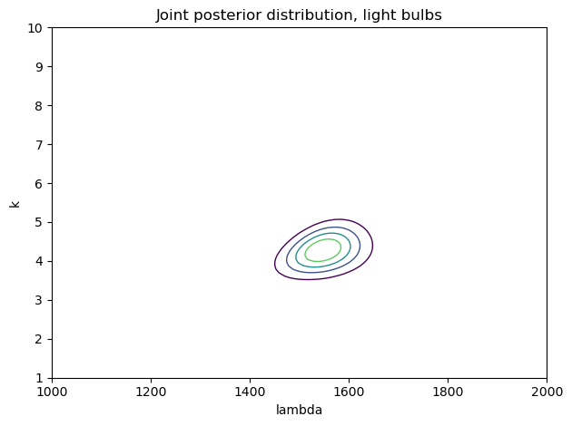

```python
plot_contour(posterior_bulb)
decorate(title='Joint posterior distribution, light bulbs')
```

## 14.05. 사후평균

#### $\lambda$와 $k$의 값을 포함하는 메쉬를 만들어서, 결합분포의 사후평균을 계산

```python
lam_mesh, k_mesh = np.meshgrid(prior_bulb.columns, prior_bulb.index)
```

#### 각 매개변수 쌍에 대해 평균 계산

```python
means = weibull_dist(lam_mesh, k_mesh).mean()
means.shape
```

```
(101, 101)
```

#### 각 매개변수 쌍에 대한 평균에, 사후결합분포에서 나온 확률을 가중치로 곱함

```python
prod = means * posterior_bulb
```

```python
prod.to_numpy().sum()
```

```
1412.7242773758671
```

#### 사후분포를 기반으로 했을 때, 전구 평균 수명은 약 1,413 시간

*위 과정을 함수로 표현*

```python
def joint_weibull_mean(joint):
    """와이블 결합분포의 평균"""
    lam_mesh, k_mesh = np.meshgrid(
        joint.columns, joint.index)
    means = weibull_dist(lam_mesh, k_mesh).mean()
    prod = means * joint
    return prod.to_numpy().sum()
```

## 14.06. 불완전 데이터

- 실험에 따르면, 연구원들은 12시간마다 전구를 확인

  **따라서 만약 연구원들이 전구가 켜진 것을 관측했다면, 마지막 확인 이후 12시간 동안 전구의 수명이 유지되었다고 기록**

**따라서, 와이블분포의 CDF를 사용하여, 관측간격 (12시간) 동안 전구가 나갈 확률을 계산**

```python
def update_weibull_between(prior, data, dt=12):
    """사전분포 갱신"""
    lam_mesh, k_mesh, data_mesh = np.meshgrid(prior.columns, prior.index, data)
    dist = weibull_dist(lam_mesh, k_mesh)
    cdf1 = dist.cdf(data_mesh)
    cdf2 = dist.cdf(data_mesh-12)
    likelihood = (cdf1 - cdf2).prod(axis=2)

    posterior = prior * likelihood
    normalize(posterior)

    return posterior
```

```python
posterior_bulb2 = update_weibull_between(prior_bulb, data_bulb)
```

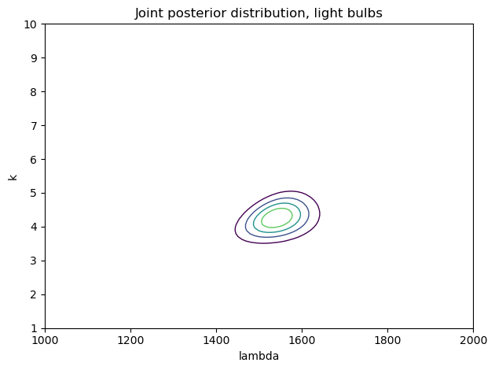

```python
plot_contour(posterior_bulb2)
decorate(title='Joint posterior distribution, light bulbs')
```

#### 이 결과는 PDF를 사용하여 얻은 결과와 거의 동일

- PDF를 사용했을 때의 사후평균

```python
joint_weibull_mean(posterior_bulb)
```

```
1412.7242773758671
```

- CDF를 사용했을 때의 사후평균

```python
joint_weibull_mean(posterior_bulb2)
```

```
1406.8171981912412
```

#### 관측치 사이의 12시간 간격을 고려하면 사후 평균은 약 6시간이 작음

## 14.07. 사후예측분포

#### 전구 100개를 설치한 후, 1000시간 후 확인하러 돌아왔을 때,

#### 각 전구의 수명이 $\lambda=1550,\;k=4.25$인 와이블분포를 따른다고 가정 $\rightarrow$ 각 전구가 나갈 확률 = 14.38%

```python
lam = 1550
k = 4.25
t = 1000

prob_dead = weibull_dist(lam, k).cdf(t)
prob_dead
```

```
0.14381685899960547
```

#### 100개의 전구가 있고, 각각 수명 확률이 있으며, 나간 전구의 수가 이항분포를 따른다고 가정

```python
from utils import make_binomial
```

```python
n = 100
p = prob_dead
dist_num_dead = make_binomial(n, p)
dist_num_dead.head()
```

|  | probs |
| --- | --- |
| 0 | 1.805790e-07 |
| 1 | 3.033265e-06 |
| 2 | 2.522079e-05 |

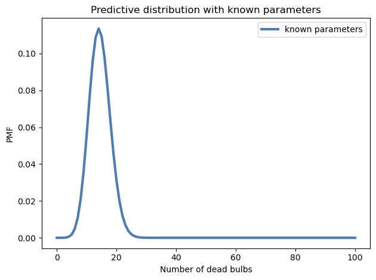

```python
dist_num_dead.plot(label='known parameters')

decorate(xlabel='Number of dead bulbs', ylabel='PMF', title='Predictive distribution with known parameters')
```

#### 하지만, 위 모든 과정은 $\lambda$와 $k$를 안다는 전제 하에서 가능

#### 따라서, 매개변수의 가능한 값과, 각각의 확률에 대한 사후분포를 알고 있기에, 이항분포에 사후확률 가중치를 부과한 혼합분포를 사용

- 사후결합분포

```python
posterior_bulb = update_weibull(prior_bulb, data_bulb)
posterior_bulb.shape
```

```
(101, 101)
```

```python
posterior_series = posterior_bulb.stack()
posterior_series.head()
posterior_series.shape
```

```
(10201,)
```

#### 가능한 매개변수 쌍을 하나씩 반복해가며, 각 쌍에 대해 예측분포를 계산

- **예측분포 (이항분포) 수열 생성**

```python
posterior_series.index
```

```
MultiIndex([( 1.0, 1000.0),
            ( 1.0, 1010.0),
            ( 1.0, 1020.0),
            ( 1.0, 1030.0),
            ( 1.0, 1040.0),
            ( 1.0, 1050.0),
            ( 1.0, 1060.0),
            ( 1.0, 1070.0),
            ( 1.0, 1080.0),
            ( 1.0, 1090.0),
            ...
            (10.0, 1910.0),
            (10.0, 1920.0),
            (10.0, 1930.0),
            (10.0, 1940.0),
            (10.0, 1950.0),
            (10.0, 1960.0),
            (10.0, 1970.0),
            (10.0, 1980.0),
            (10.0, 1990.0),
            (10.0, 2000.0)],
           names=['k', 'lambda'], length=10201)
```

```python
pmf_seq = []

for (k, lam) in posterior_series.index:
    prob_dead = weibull_dist(lam, k).cdf(t)
    pmf = make_binomial(n, prob_dead)
    pmf_seq.append(pmf)
```

```python
len(pmf_seq)
```

```
10201
```

#### 사후확률과, 이항분포 수열을 활용하여 사후예측분포 생성

```python
from utils import make_mixture
```

```python
post_pred = make_mixture(posterior_series, pmf_seq)
```

```python
(np.unique(pd.DataFrame(posterior_series).reset_index()['lambda'])).shape
```

```
(101,)
```

#### 매개변수에 대한 불확실성은, 나간 전구의 수에 대한 불확실성을 반영하는 만큼 사후예측분포가 더 넓게 분포

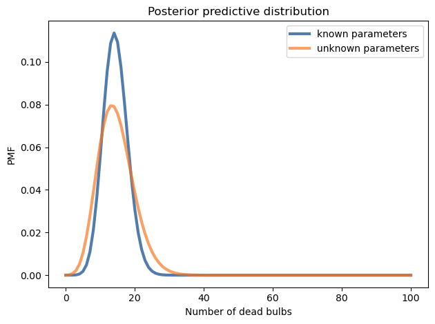

```python
dist_num_dead.plot(label='known parameters')
post_pred.plot(label='unknown parameters')
decorate(xlabel='Number of dead bulbs', ylabel='PMF', title='Posterior predictive distribution')
```